# Deep-NLP

Delermando Branquinho Filho

30 de abril de 2017

# The simple way to classify texts

### Source

After download the sources from:

[MyGithub](https://github.com/TheScientistBr/deep-NLP)

`all files and directories works fine at last time 04/30/2017 3:33 pm`

## Dataset

The first step is: Loading Dataset from [Kaggle](https://www.kaggle.com/samdeeplearning/deepnlp/kernels)

Credits dataset: samdeeplearning

## Loading sources and executing

At this step just TF-IDF will be created

```r
source("createTFIDF.R")
head(book_words)
```

```
##          file     word n total    tf       idf     tf_idf       class
## 1: response_1      and 1     8 0.125 0.6443570 0.08054463 not_flagged
## 2: response_1    avoid 1     8 0.125 4.3820266 0.54775333 not_flagged
## 3: response_1 conflict 1     8 0.125 4.3820266 0.54775333 not_flagged
## 4: response_1        i 1     8 0.125 0.4700036 0.05875045 not_flagged
## 5: response_1       of 1     8 0.125 0.9808293 0.12260366 not_flagged
## 6: response_1     sort 1     8 0.125 4.3820266 0.54775333 not_flagged
```

## Creating centroids

Loading source and creating centroids with .7 to training, .3 to test

```r
source("createClassCentroid.R")
createClassCentroid()
createFiles2Test()
```

### Classifying

After training we’ll classify, but before will demostrate a graphical represetation of this classification. We’ll use couple of files `response_1` and `response_49`

```r
source("plotFiles.R")
par(mfrow=c(1,2))
plotFile(file1 = "response_1",wplot = TRUE,classCentroid = "flagged")
```

```
## [1] 0.3026763
```

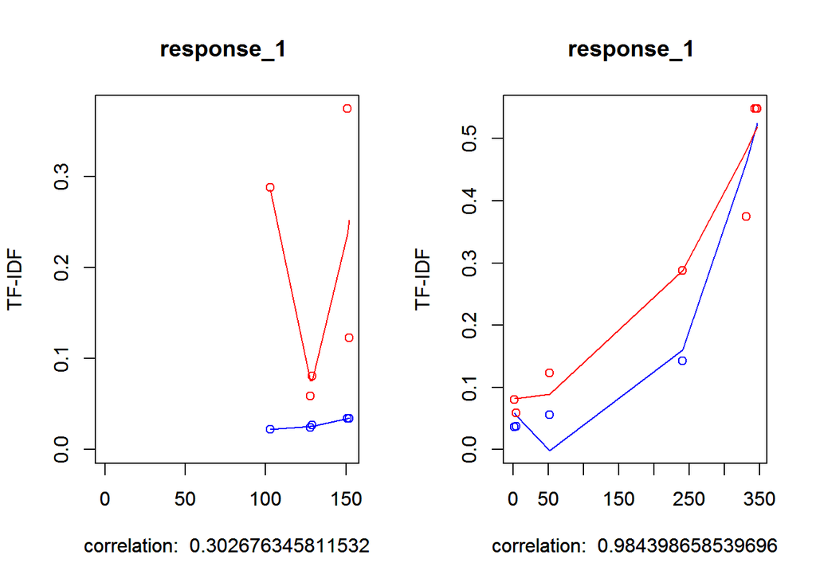

```
## [1] 0.9843987
```

```r
plotFile(file1 = "response_1",wplot = TRUE,classCentroid = "not_flagged")
```

Just take a look about correlation of predictors, strong for not_flagged and weak for flagged, like we expected. Now, we take a look about response_49.

```r
ind <- which(book_words$file == "response_1")
book_words[ind,]
```

```
##          file     word n total    tf       idf     tf_idf       class
## 1: response_1      and 1     8 0.125 0.6443570 0.08054463 not_flagged
## 2: response_1    avoid 1     8 0.125 4.3820266 0.54775333 not_flagged
## 3: response_1 conflict 1     8 0.125 4.3820266 0.54775333 not_flagged
## 4: response_1        i 1     8 0.125 0.4700036 0.05875045 not_flagged
## 5: response_1       of 1     8 0.125 0.9808293 0.12260366 not_flagged
## 6: response_1     sort 1     8 0.125 4.3820266 0.54775333 not_flagged
## 7: response_1     this 1     8 0.125 2.9957323 0.37446653 not_flagged
## 8: response_1      try 1     8 0.125 2.3025851 0.28782314 not_flagged
```

```r
par(mfrow=c(1,2))
plotFile(file1 = "response_49",wplot = TRUE,classCentroid = "flagged")
```

```
## [1] 0.674903
```

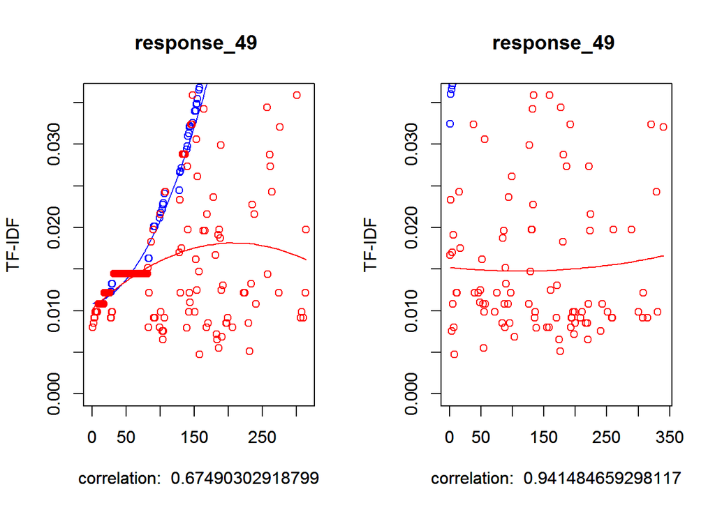

```
## [1] 0.9414847
```

```r
plotFile(file1 = "response_49",wplot = TRUE,classCentroid = "not_flagged")
```

Wrong decision! Now we run this test for all files and extract the acuracy from Zipf Law Algortm.

```r
ind <- which(book_words$file == "response_49")
book_words[ind,]
```

```
##             file    word  n total          tf       idf      tf_idf
##   1: response_49       a 11   304 0.036184211 0.8266786 0.029912712
##   2: response_49   about  1   304 0.003289474 1.6739764 0.005506501
##   3: response_49  advice  1   304 0.003289474 2.7725887 0.009120358
##   4: response_49     all  1   304 0.003289474 2.7725887 0.009120358
##   5: response_49 already  1   304 0.003289474 4.3820266 0.014414561
##  ---
## 161: response_49    will  2   304 0.006578947 3.2834143 0.021601410
## 162: response_49    with  5   304 0.016447368 1.1631508 0.019130770
## 163: response_49   would  3   304 0.009868421 2.7725887 0.027361073
## 164: response_49    year  1   304 0.003289474 3.2834143 0.010800705
## 165: response_49   years  3   304 0.009868421 3.2834143 0.032402115
##        class
##   1: flagged
##   2: flagged
##   3: flagged
##   4: flagged
##   5: flagged
##  ---
## 161: flagged
## 162: flagged
## 163: flagged
## 164: flagged
## 165: flagged
```

**Flagged Class**

```r
source("iClassFile.R")
printf <- function(...) invisible(print(sprintf(...)))
f1 <- iClassFileAll(iclass = "flagged")[4]
```

```
##    iclass
## 1 flagged
```

```r
printf("Flagged Class Accuracy (F1): %f",f1)
```

```
## [1] "Flagged Class Accuracy (F1): 0.750000"
```

**Not Flagged Class**

```r
f1 <- iClassFileAll(iclass = "not_flagged")[4]
```

```
##        iclass
## 1 not_flagged
```

```r
printf("not_Flagged Class Accuracy (F1): %f",f1)
```

```
## [1] "not_Flagged Class Accuracy (F1): 0.705882"
```

## Ploting Words from files

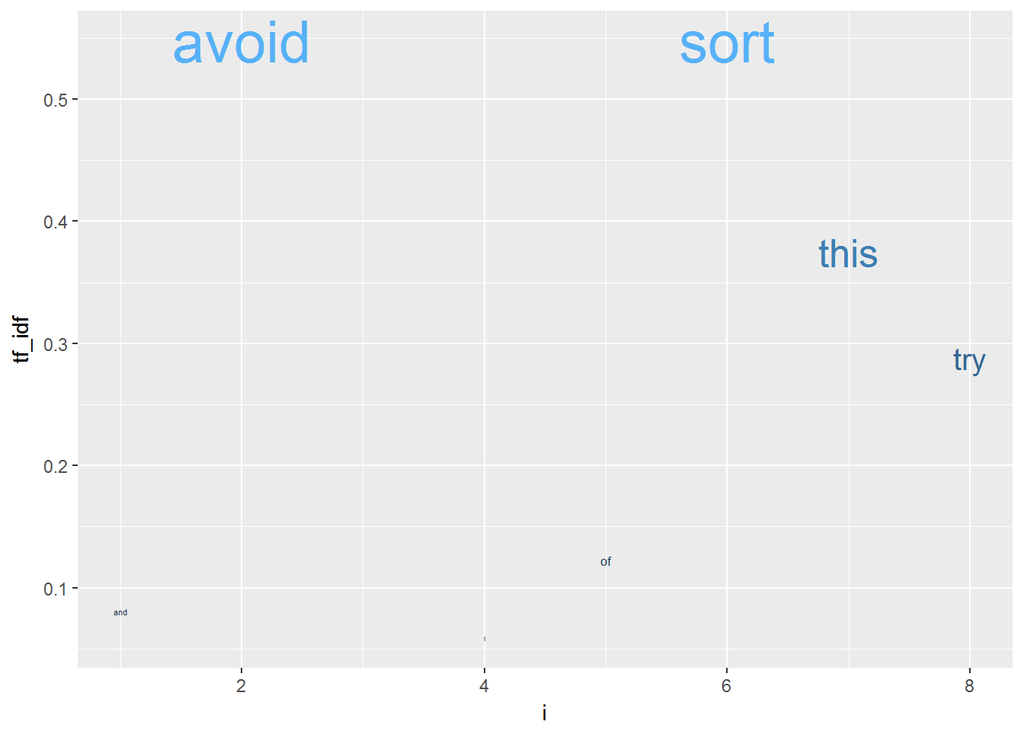

```
##
## Call:
## lm(formula = doc$tf_idf ~ doc$i + I(doc$i^2))
##
## Coefficients:
## (Intercept)        doc$i   I(doc$i^2)
##    0.224367     0.044817    -0.004122
```

```r
plotWords("response_1")
```

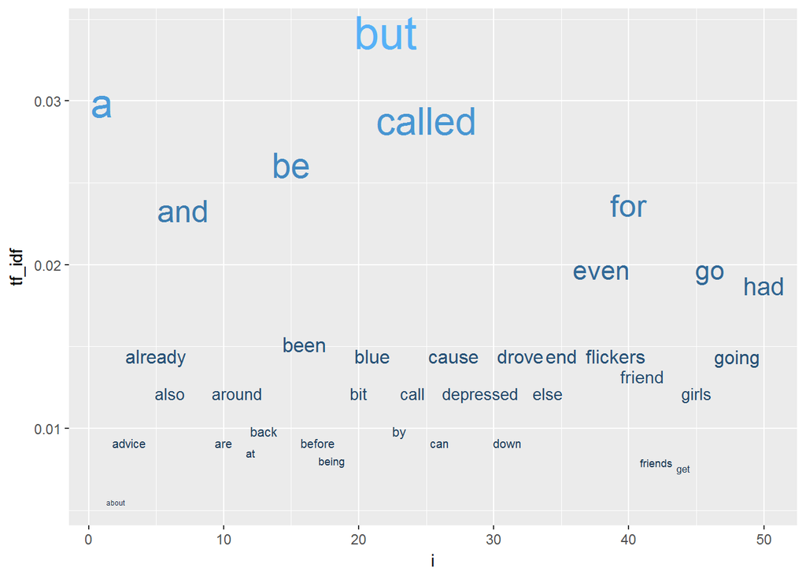

```
##
## Call:
## lm(formula = doc$tf_idf ~ doc$i + I(doc$i^2))
##
## Coefficients:
## (Intercept)        doc$i   I(doc$i^2)
##   1.437e-02   -5.402e-05    1.463e-06
```

```r
plotWords("response_49")
```

[The Scientist](http://www.thescientist.com.br)